# 70619 - Analyze capture-mark-recapture data using *mrmr*

Roland Knapp

## Install latest versions of cmdstanr, cmdstan, and mrmr packages

Run only if updated versions were released since previous install

```r
# install cmdstanr and cmdstan
install.packages("cmdstanr", repos = c("https://mc-stan.org/r-packages/", getOption("repos")))
cmdstanr::install_cmdstan()

# install mrmr
remotes::install_github("SNARL1/mrmr")
```

## Load required packages

```r
library(dplyr)
library(readr)
library(tibble)
library(cmdstanr)
library(mrmr)
library(patchwork)
```

## Create required data frames

```r
captures <- read_csv(here::here("data", "clean", "70619_capture.csv"))
surveys <- read_csv(here::here("data", "clean", "70619_survey.csv"))
translocations <- read_csv(here::here("data", "clean", "70619_translocation.csv"))
```

## Check datasets

```r
data_70619 <- clean_data(captures = captures, surveys = surveys, translocations = translocations)
```

## Fit model

Add “adapt_delta = 0.99” or similar if divergent transitions occur.

```r
model_70619 <- fit_model(
                    data = data_70619,
                    chains = 4,
                    parallel_chains = 4,
                    cpp_options = list(stan_threads = TRUE),
                    threads_per_chain = 2)
```

```
Model executable is up to date!
```

```
Running MCMC with 4 parallel chains, with 2 thread(s) per chain...

Chain 1 Iteration:    1 / 2000 [  0%]  (Warmup)
Chain 2 Iteration:    1 / 2000 [  0%]  (Warmup)
```

[output not shown]

```
Chain 3 Iteration:    1 / 2000 [  0%]  (Warmup)
```

[output not shown]

[output not shown]

[output cut: 38 more lines]

```
Chain 4 Iteration: 1900 / 2000 [ 95%]  (Sampling)
Chain 2 Iteration: 2000 / 2000 [100%]  (Sampling)
Chain 2 finished in 18.6 seconds.
Chain 3 Iteration: 2000 / 2000 [100%]  (Sampling)
Chain 3 finished in 18.8 seconds.
Chain 4 Iteration: 2000 / 2000 [100%]  (Sampling)
Chain 4 finished in 19.0 seconds.
Chain 1 Iteration: 1800 / 2000 [ 90%]  (Sampling)
Chain 1 Iteration: 1900 / 2000 [ 95%]  (Sampling)
Chain 1 Iteration: 2000 / 2000 [100%]  (Sampling)
Chain 1 finished in 20.8 seconds.

All 4 chains finished successfully.
Mean chain execution time: 19.3 seconds.
Total execution time: 20.9 seconds.
```

- Running model with default adapt_delta (0.8) resulted in zero divergent transition (0/4000).

### Save/retrieve model object

This step prevents having to rerun the model in the event of a crash during model visualizations in subsequent code blocks. Model files can be large, so this saves the file in a compressed format.

```r
write_rds(model_70619, here::here("out", "model", "70619_model.rds"), "xz", compression = 9L)
```

```r
model_70619 <- read_rds(here::here("out", "model", "70619_model.rds"))
```

### Diagnose potential non-convergence of the MCMC algorithm

Inspect traceplots and parameter summary table. In table, are any R<sub>hat</sub> values $\ge 1.01$?

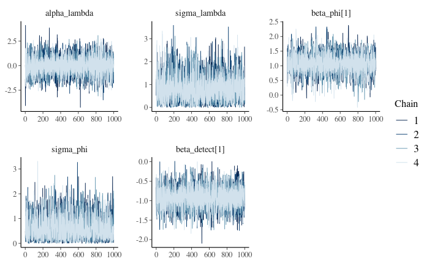

```r
pars_to_plot <- c('alpha_lambda',
                  'sigma_lambda',
                  'beta_phi',
                  'sigma_phi',
                  'beta_detect')
bayesplot::mcmc_trace(model_70619$m_fit$draws(pars_to_plot))
```

```r
model_70619$m_fit$summary(pars_to_plot)
```

| variable | mean | median | sd | mad | q5 | q95 | rhat | ess_bulk | ess_tail |
| --- | --- | --- | --- | --- | --- | --- | --- | --- | --- |
| alpha_lambda | 0.0008216327 | -0.01617175 | 1.0108088 | 1.0239988 | -1.64174050 | 1.6495940 | 1.000702 | 6145.214 | 2588.589 |
| sigma_lambda | 0.7909059917 | 0.65955800 | 0.5987179 | 0.5753793 | 0.05768834 | 1.9561205 | 1.000514 | 3096.024 | 1685.011 |
| beta_phi[1] | 1.0733860411 | 1.07233500 | 0.3477396 | 0.3176307 | 0.50537830 | 1.6440165 | 1.001192 | 2466.623 | 1739.544 |
| sigma_phi | 0.6211295958 | 0.51546000 | 0.4808430 | 0.4609693 | 0.04935466 | 1.5735745 | 1.000318 | 2413.959 | 2355.828 |
| beta_detect[1] | -0.9202817832 | -0.91571800 | 0.2833968 | 0.2755709 | -1.40135850 | -0.4634856 | 1.001473 | 6076.502 | 2830.623 |

## Visualize model results

### Default plots

Note: Custom plots (produced in next code chunk: “plots_custom”) are often easier to interpret than the default plots produced by this code chunk.

```r
plot_model(model_70619, what = "abundance")
plot_model(model_70619, what = "recruitment")
plot_model(model_70619, what = "survival")
```

[output not shown]

### Customize plots

```
geom_path: Each group consists of only one observation. Do you need to adjust the group aesthetic?
geom_path: Each group consists of only one observation. Do you need to adjust the group aesthetic?
geom_path: Each group consists of only one observation. Do you need to adjust the group aesthetic?
geom_path: Each group consists of only one observation. Do you need to adjust the group aesthetic?
```

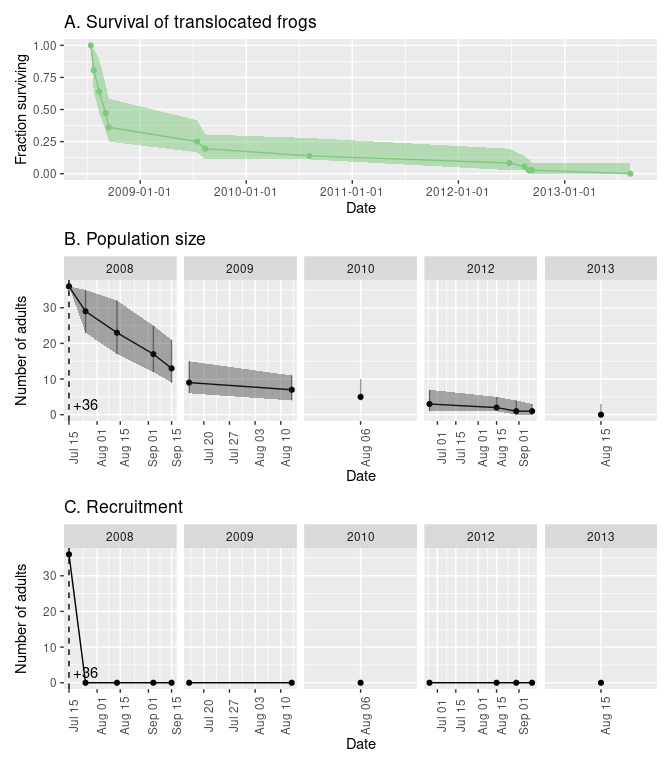

```r
library(ggplot2)
p1 <- plot_model(model_70619, what = "survival")
p1 <- p1 + ggtitle("A. Survival of translocated frogs") +
    expand_limits(y = 0) +
    theme(legend.position = "none")

p2 <- plot_model(model_70619, what = "abundance")
p2 <- p2 + ggtitle("B. Population size") +
    ylab("Number of adults") +
    expand_limits(y = 0)

p3 <- plot_model(model_70619, what = "recruitment")
p3 <- p3 + ggtitle("C. Recruitment") +
    ylab("Number of adults")

p1 / p2 / p3
```

### Save custom plots

```r
ggsave(here::here("out", "plots", "70619_mrmr_plots.png"), width = 6.5, height = 7.2)
```

```
geom_path: Each group consists of only one observation. Do you need to adjust the group aesthetic?
geom_path: Each group consists of only one observation. Do you need to adjust the group aesthetic?
geom_path: Each group consists of only one observation. Do you need to adjust the group aesthetic?
geom_path: Each group consists of only one observation. Do you need to adjust the group aesthetic?
```

## Create survival tables

Only the cohort-level survival table is displayed (individual-level survival can be a large table).

```r
survival_cohort <- survival_table(model_70619, by_cohort = TRUE)
survival_cohort
```

| years_since_introduction | release_date | lo_survival | median_survival | hi_survival |
| --- | --- | --- | --- | --- |
| 0 | 2008-07-15 | 0.45833333 | 0.56944444 | 0.74305556 |
| 1 | 2008-07-15 | 0.13888889 | 0.22222222 | 0.36111111 |
| 2 | 2008-07-15 | 0.11111111 | 0.13888889 | 0.27777778 |
| 4 | 2008-07-15 | 0.01388889 | 0.04861111 | 0.12500000 |
| 5 | 2008-07-15 | 0.00000000 | 0.00000000 | 0.08333333 |

```r
survival_ind <- survival_table(model_70619, by_individual = TRUE)
```

### Save survival tables

```r
survival_cohort %>% write_csv(here::here("out", "tables", "70619_survival_cohort.csv"))
survival_ind %>% write_csv(here::here("out", "tables", "70619_survival_ind.csv"))
```